# Simulating CO T->P leakage from bandpass mismatch

In my [previous posting](http://giuspugl.github.io/reports/CO_sims.html) I've shown how the bandpass mismatches due to CO 1-0 line leak into Q , U polarization maps.

[figure not shown]

**Caption** Cartoon of bandpass mismatch. Credits Toki Suzuki.

We model the mismatch for both detector bandpass around the CO line ( see figure above) as

$$ d^A_t = f s_{CO} $$ $$ d^B_t = \epsilon f s_{CO} $$

where $f$ and $\epsilon $ parametrize the bandpass mismatch of the detector pair and $s_{CO} $ is the scanned CO intensity only map (see above, no polarization). So far we consider $f$ and $\epsilon $ constant during the whole observation period: ($f= 0.5 $ and $\epsilon = 0.3 $ )

We injected bandpass mismatches by simulating 1 yr of LB signal -only observations performed by 2 detector pair.

We therefore want to assess the level of T-> P leakage from CO lines to QU maps.

```python
import pylab as pl
from  numpy.random import normal
import numpy as np
import healpy as hp
from scipy.signal import periodogram
from pylab import cm
cmap = cm.get_cmap('RdYlBu')
cmap.set_under('w')
```

```python
from IPython.display import HTML

HTML('''<script>
code_show=true;
function code_toggle() {
 if (code_show){
 $('div.input').hide();
 } else {
 $('div.input').show();
 }
 code_show = !code_show
}
$( document ).ready(code_toggle);
</script>
<form action="javascript:code_toggle()"><input type="submit" value="Click here to toggle on/off the raw code."></form>''')
```

## Input Planck Commander Maps

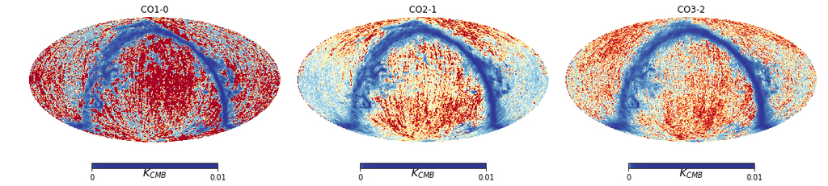

```python
co10Ke = hp.read_map(dirmaps+'COM_CompMap_CO10-commander_0256_R2.00_E.fits', verbose=False , nest=True)
co21Ke = hp.read_map(dirmaps+'COM_CompMap_CO21-commander_0256_R2.00_E.fits', verbose=False , nest=True)
co32Ke = hp.read_map(dirmaps+'COM_CompMap_CO32-commander_0256_R2.00_E.fits', verbose=False , nest=True)

fig=pl.figure(figsize=(15,8))
hp.mollview(co10Ke, cmap=cmap, nest=True, sub=131,max=.01, fig=fig,norm='hist', title= ' CO1-0 '  , unit= r'$K_{CMB}$ ')
hp.mollview(co21Ke, cmap=cmap, nest=True, sub=132,max=.01 , fig=fig,norm='hist', title= ' CO2-1 ' , unit=  r'$K_{CMB}$ ')
hp.mollview(co32Ke, cmap=cmap, nest=True, sub=133,max=.01, fig=fig,norm='hist', title= ' CO3-2 ' , unit=  r'$K_{CMB}$ ')
```

## Sims w/ CO 1-0

In case of signal only sims, Madam destriper doesn't converge since the band mismatches don't behave as a common baseline to be fitted in the timestream; therefore I just considered *binned coadded maps*.

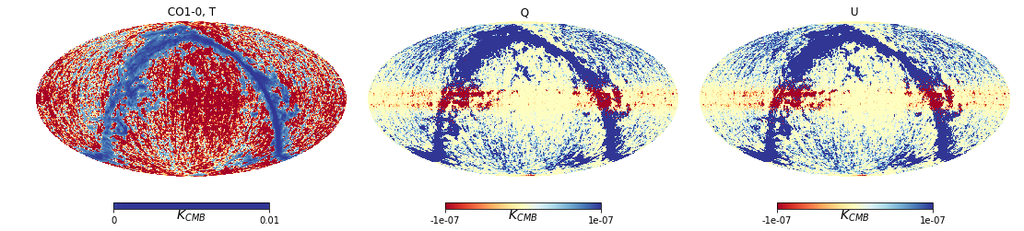

```python
%matplotlib inline
mco10b= hp.read_map('../CO_bandpass/madam_bmap_003.fits', field=range(3), verbose=False)

fig=pl.figure(figsize=(15,8))
mco10b[0]/=0.5
hp.mollview(mco10b[0] , cmap=cmap , sub=131, fig=fig,norm='hist',max=.01,min=0., title= ' CO1-0, T '  , unit= r'$K_{CMB}$ ')
hp.mollview(mco10b[1] , cmap=cmap , sub=132, fig=fig , title= '  Q ' , unit=  r'$K_{CMB}$ ', min=-1e-7, max=1e-7)
hp.mollview(mco10b[2], cmap=cmap , sub=133, fig=fig ,  title= ' U ' , unit=  r'$K_{CMB}$ ', min=-1e-7, max=1e-7)
```

We apply to the output maps a CO mask, excluding all the CO emission larger than $10 \mu $K, (obtained with a 5 deg smoothing of the Commander CO 10 map). Apodization length 1 deg, ($f_{sky}= 0.80$)

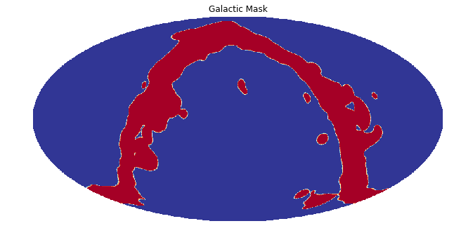

```python
mask=hp.read_map('../CO_bandpass/apodized_mask_1.fits',
                 verbose=False)

hp.mollview(mask,title='Galactic Mask' , cbar=False, cmap=cmap)
```

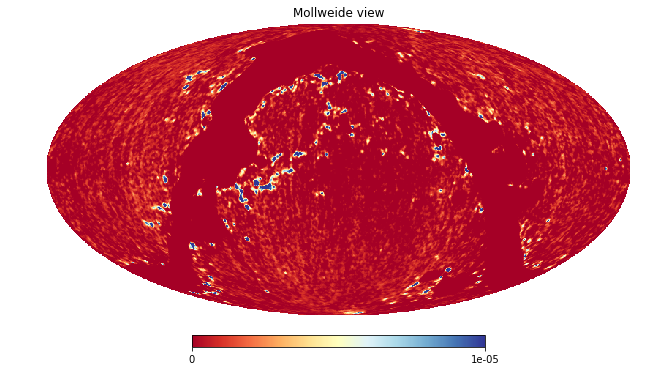

```python
hp.mollview(mask *mco10b[0],  max=1e-5, cmap=cmap )
```

Finally, we estimate the BB power spectra by means of the pure estimator ( Grain et al 2009, Smith et al. 2006), by applying a Galactic mask to the maps. We also corrected by :

$$ f^2 (1- \epsilon)^2 \hat{C}_b $$ being $\hat{C}_b$ the estimated binned pure B power spectrum.

```python
cl = pl.loadtxt('../Class_planck2015_r0_cl_lensed.dat')
lmax=3*hp.get_nside(mco10b)
l=pl.arange(2, lmax+1)
Nl =lambda w: (pl.pi /180. /60. * w)**2
wp=7.6 # uK arcmin
Nl0= Nl(wp)
cb = hp.read_cl('../CO_bandpass/cell__CO10_ring_binned_map_mask1_0_0.fits')
```

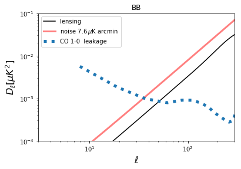

```python
f=0.5
eps=0.3
ll = l*(l+1)/2./pl.pi
pl.title('BB')
pl.loglog(l, cl[ 2:lmax+1,3] *ll   ,'k', label='lensing')
pl.xlabel(r'$\ell$', fontsize=16)
pl.ylabel(r'$D_{\ell}    [ \mu K^2 ]$', fontsize=16)
pl.loglog(l, ll *Nl0,'r', alpha=.5, linewidth=3, label='noise '+r'$7.6 \,\mu $K arcmin ')

pl.loglog(cb[0], cb[3]*1e12*f**2*(1-eps)**2,':', lw=5, label='CO 1-0  leakage' )
pl.legend()
pl.ylim([1e-4,1e-1])
foo=pl.xlim([3 ,300])
```